# Beyond Physical Labor: The Gendered Mental Load of Shopping and Household Management

Dr Preet Deep Singh[^1]

November 11, 2025

Abstract

Using a 10% random sample of India’s 2019 Time Use Survey (10.2 million person-day observations from 139,489 households), we examine gender gaps in shopping and household management—activities that provide observable indicators of the “mental load” of planning, organizing, and coordinating domestic life. Women spend substantially more time than men on shopping and are significantly more likely to participate in these activities. Among married individuals, the gender gap widens dramatically, revealing that marriage shifts planning and procurement responsibilities onto wives. This pattern persists across all education levels, urban-rural locations, and employment status, suggesting that the mental load remains invisible and undervalued even as physical household tasks become more equally shared. We find that employed women face a “double planning burden”—they maintain high levels of shopping activity despite time constraints from paid work, while employed men’s shopping time is unchanged. These findings have important implications for understanding gender inequality beyond visible physical labor, highlighting how cognitive and organizational work remains stubbornly feminized.

**JEL Classification:** J12, J16, D13, I31

**Keywords:** mental load, shopping, household management, gender inequality, unpaid work, India

# 1 Introduction

The concept of “mental load” has emerged as a crucial but often invisible dimension of gender inequality in households. Beyond the physical tasks of cooking, cleaning, and childcare, someone must plan meals, remember birthdays, schedule appointments, coordinate family logistics, track household supplies, and make countless daily decisions about domestic life. This cognitive and emotional labor—anticipating needs, planning ahead, delegating tasks, and bearing responsibility for household functioning—constitutes what researchers call the mental load (Hartley 2018; Daminger 2019).

Crucially, the mental load is gendered. Even in households where physical tasks are shared relatively equally, women typically bear disproportionate responsibility for the cognitive work of household management: deciding what groceries to buy, remembering when children need new clothes, tracking which bills are due, and coordinating family schedules (Ciciolla and Luthar 2019). This invisible labor is time-consuming, stressful, and difficult to outsource or share.

Measuring mental load empirically is challenging because much of it occurs “in the background” of daily life—a running mental checklist that women maintain even while doing other activities. However, certain observable activities provide windows into this cognitive work. **Shopping for goods and services** (deciding what to buy, comparing prices, traveling to stores) and **household management** (bill payment, coordinating repairs, managing finances) are activities that directly reflect planning, decision-making, and organizational responsibilities.

Using a 10% random sample of India’s 2019 Time Use Survey (10.2 million person-day observations from 139,489 households), we examine gender gaps in shopping and household management activities. We document substantial gender asymmetries in these activities that provide observable indicators of the “mental load” of household planning and organization. While time-use data cannot directly measure cognitive burden (planning, remembering, coordinating), these activities involve planning and decision-making that likely reflect the broader mental load. Among all individuals, women spend substantially more time on shopping than men, and among married individuals, this gap widens significantly, suggesting that marriage transfers cognitive household responsibilities to wives.

Several findings support the “mental load” interpretation rather than mere task division:

1. **Shopping gaps persist among employed women**: Employed women maintain high levels of shopping activity regardless of paid work constraints, while employed men’s shopping time remains low and unchanged.
2. **Education does not reduce the gap**: Highly educated women spend substantially more time shopping than highly educated men. Education, which predicts more egalitarian attitudes, does not translate into shared mental load.
3. **Urban-rural patterns are similar**: The gender gap in shopping persists across both urban and rural areas. Modernization and exposure to egalitarian norms do not appear to shift planning work.
4. **Marriage amplifies the gap**: The female-male shopping ratio is substantially higher among married couples than among never-married individuals. Marriage creates or intensifies the expectation that wives manage household logistics.

Our findings have important implications for understanding gender inequality. Policy discussions often focus on visible household labor (cooking, cleaning, childcare) and advocate for better task-sharing. But if women continue to bear the mental load—the responsibility to plan, organize, remember, and coordinate—then apparent progress in task-sharing may be superficial. Men may “help” with specific tasks when asked, but women remain household managers who must identify needs, delegate, and follow up.

This paper proceeds as follows. Section 2 reviews literature on mental load and invisible domestic labor. Section 3 describes the Time Use Survey data and our measurement approach. Section 4 presents descriptive patterns of shopping and household management by gender. Section 5 reports regression results with controls and tests for heterogeneity. Section 6 discusses mechanisms and policy implications.

# 2 Literature Review

## 2.1 The Mental Load: Beyond Physical Labor

Economic models of household production traditionally focus on observable tasks: cooking, cleaning, childcare, and other activities that produce household services (Becker 1981; Gronau 1977). Time use surveys, the primary data source for studying unpaid work, similarly capture time spent on specific activities but miss the cognitive dimension of household management (Kan and Pudney 2008).

Recent feminist scholarship emphasizes that household labor involves not just execution but also **cognitive work**: planning what needs to be done, remembering deadlines and appointments, anticipating needs, making decisions, and bearing responsibility for ensuring tasks are completed (Daminger 2019; Walzer 1996). This “worry work” or “mental load” is time-consuming, stressful, and difficult to share because it involves ongoing awareness and accountability rather than discrete tasks.

Hartley (2018) argues that the mental load may be more consequential for gender inequality than physical tasks because: 1. It is invisible and thus undervalued 2. It cannot be easily outsourced or delegated 3. It fragments attention, making it harder to focus on paid work or leisure 4. It persists even when physical tasks are shared

Daminger (2019) identifies four components of cognitive labor: anticipating needs, identifying options, making decisions, and monitoring outcomes. Through time-diary and interview data from US couples, she finds that even in “egalitarian” households where men perform many physical tasks, women overwhelmingly handle the cognitive work—deciding what’s for dinner, researching childcare options, remembering medical appointments.

Ciciolla and Luthar (2019) document mental health consequences of the mental load: mothers report higher stress, anxiety, and emotional exhaustion related to their role as “household managers” independent of time spent on physical tasks. Dean et al. (2022) find that the mental load increased during COVID-19, with mothers bearing intensified responsibility for coordinating remote schooling, managing health protocols, and planning household logistics during lockdowns. Carlson et al. (2020) show that cognitive labor (anticipating needs, planning, organizing) is more strongly associated with parental stress than physical childcare time, suggesting that mental load may be a key mechanism linking gender inequality to wellbeing gaps.

## 2.2 Measuring Mental Load with Time Use Data

While mental load is inherently difficult to capture with conventional time use surveys, certain activities provide observable proxies:

**Shopping for goods and services**: Grocery shopping, purchasing household items, comparing products and prices involves decision-making (what to buy?), planning (what will we need?), and information-gathering. The person who does the shopping typically also decides what gets purchased, making this activity a measure of procurement planning.

**Household management**: Bill payment, financial management, coordinating repairs and services, dealing with administrative tasks captures organizational and planning responsibilities.

Several studies use shopping as an indicator of household planning responsibilities. Bonke (2019), using Danish time-use data, finds that women do 65% of household shopping and that this gap persists even in dual-earner couples. Sayer (2005) documents that shopping and household management are among the least equally shared household activities in the US, with women doing 2-3 times as much as men. Sullivan (2013) analyzes time-use trends across multiple countries and finds that while some physical household tasks have become more gender-equal over time, shopping and household management remain stubbornly feminized.

Studies from developing countries are scarce. Arora (2015) examines India’s 1998-99 Time Use Survey and finds that women spend substantially more time on shopping and procurement, but does not explore heterogeneity by marital status, education, or employment. Kulkarni (2020) examines time poverty among rural Indian women and identifies procurement and market-related activities as major time burdens that constrain employment opportunities.

## 2.3 Gender, Marriage, and Household Specialization

Theories of household specialization predict that couples divide labor based on comparative advantage, typically with women specializing in home production (Becker 1981). However, recent work challenges this framework by documenting persistent gender gaps even when women are employed and have similar earnings to their partners (Bittman et al. 2003).

Alternative theories emphasize “doing gender”—the idea that household task allocation reflects and reinforces gender identity (West and Zimmerman 1987). Shopping and household management may be particularly gendered because they involve caregiving aspects (planning meals for family, ensuring household needs are met) that are culturally associated with femininity and motherhood. Offer and Schneider (2011) argue that intensive parenting norms have increased the cognitive demands on mothers, who must research, plan, and coordinate children’s activities and development even when fathers participate in physical care.

Craig and Mullan (2011) analyze time-use data from multiple countries and find that the “planning” component of household work is more gendered than execution. Even when couples share cooking, women typically plan menus and create shopping lists. Lachance-Grzela and Bouchard (2010) conduct a meta-analysis of household labor division and find that cognitive household work (planning, organizing, remembering) shows larger gender gaps than physical tasks across multiple countries and decades.

For India specifically, marriage is associated with sharp increases in women’s domestic work and decreases in their labor force participation (Klasen and Pieters 2015). Desai and Andrist (2010) document how patrilocal marriage patterns in India shift young brides into intensive domestic labor roles in their husbands’ households. Whether this extends to cognitive household labor is unknown.

## 2.4 Employment and the Double Burden

A key question is whether employed women reduce their household planning time or face a “double burden” of paid work plus full mental load. Studies from developed countries find that employed women reduce some physical household tasks (especially cleaning) but maintain responsibility for planning and management (Bianchi et al. 2000; Sayer 2005).

If men do not increase their planning time when their wives are employed, this suggests that the mental load is particularly rigid and resistant to economic pressure.

# 3 Data and Measurement

## 3.1 India’s Time Use Survey 2019

Activities are classified using the International Classification of Activities for Time Use Statistics (ICATUS), with 3-digit detail. For this study, we focus on two specific categories that capture mental load:

- **Activity Code 34**: Shopping for goods and services (grocery shopping, purchasing clothes, comparing products, traveling to markets/stores, etc.)
- **Activity Code 35**: Household management (paying bills, financial management, coordinating repairs and services, administrative tasks)

Table 0 shows the prevalence of these activities in our sample.

Prevalence of Shopping and Household Management Activities by Gender

| Gender | Total N | Shopping (Code 34) N | Shopping (Code 34) % | Household Mgmt (Code 35) N | Household Mgmt (Code 35) % | Either Activity N | Either Activity % |
| --- | --- | --- | --- | --- | --- | --- | --- |
| Female | 447,303 | 12,804 | 2.92 | 579 | 0.14 | 13,383 | 3.05 |
| Male | 388,749 | 664 | 0.16 | 259 | 0.07 | 923 | 0.23 |

As Table 0 shows, shopping and household management are relatively infrequent activities on any single day. Among women, approximately 2.9% engage in shopping and 0.1% engage in household management on the diary day. For men, these rates are 0.2% and 0.1% respectively. This low daily participation is expected—most people do not shop every day—but it means our results primarily capture who bears responsibility for these tasks (the extensive margin) rather than intensive time use conditional on participation.

## 3.2 Measurement Challenges

We acknowledge several important measurement limitations that affect interpretation:

**1. Can’t distinguish planner from executor (CRITICAL LIMITATION)**: Time-use data tells us who physically went shopping but not who decided what to buy, created the shopping list, or made purchasing decisions. If a man goes shopping but his wife planned the trip, made the list, and decided what to purchase, the cognitive work (mental load) was done by the wife even though the behavioral data shows the husband shopping. This means our estimates may **understate** true mental load gender gaps, as women may bear planning responsibility even when men execute the task.

**2. Lower bound on mental load**: Shopping and household management capture only the *visible* components of mental load—time spent physically shopping or managing finances. The cognitive work of planning what to buy, remembering what’s needed, mentally tracking household inventories, and coordinating logistics occurs “in the background” and is not captured by time diaries. Thus our estimates represent a **lower bound** on total mental load gender gaps. The true cognitive burden likely exceeds what we observe.

Despite these limitations, shopping and household management time remain useful indicators of gendered household responsibilities, particularly when examining patterns across marital status, employment, and education.

## 3.3 Key Variables

**Shopping participation**: Binary indicator for whether the individual spent any time on shopping (Activity Code 34) as their primary activity on the diary day.

**Shopping time**: Total minutes spent on shopping including both participants and non-participants. This is our main outcome, as it captures both the extensive margin (whether to shop) and intensive margin (how much time if shopping).

**Household management**: Similar binary indicator and minutes for Activity Code 35.

**Mental load**: Combined measure—any time on shopping OR household management.

**Gender**: Male, female, or transgender. We focus primarily on male-female comparisons.

**Marital status**: Never married, currently married, widowed, or divorced/separated. Main analyses focus on married individuals.

**Controls**: Age, education level (primary or less, secondary, higher education), urban vs. rural residence, employment status, and state fixed effects.

## 3.4 Sample Construction

We restrict analysis to **major activities only** (Major_Activity_Flag = 1), which captures time slots where shopping/management was the primary activity. This avoids double-counting and focuses on substantial episodes.

# 4 Descriptive Patterns

## 4.1 Overall Gender Gaps in Shopping and Household Management

Table 1 shows participation rates and time spent on shopping and household management by gender.

Shopping and Household Management by Gender

| Gender | Shopping Participation (%) | Shopping Minutes/Day | Household Management Participation (%) | Household Management Minutes/Day | N |
| --- | --- | --- | --- | --- | --- |
| Female | 2.92 | 1.50 | 0.14 | 0.10 | 447,303 |
| Male | 0.16 | 0.07 | 0.07 | 0.04 | 388,749 |

Women are substantially more likely than men to engage in shopping and household management:

- **Shopping participation**: Women are 18.5x more likely to shop (2.9% vs. 0.2% daily)
- **Shopping time**: Women average 1.5 minutes/day, men 0.1 minutes (22.8:1 ratio)
- **Household management**: Women do 2.6x as much household management as men

## 4.2 Visualizing the Shopping Gap

Figure 1 illustrates time spent on shopping by gender.

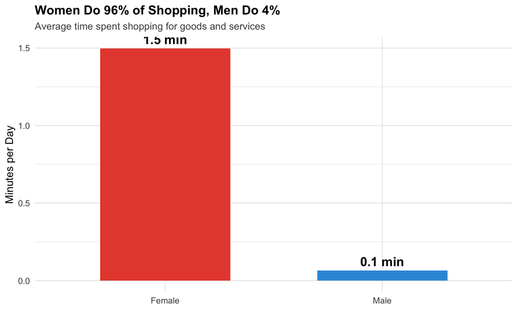

The Shopping Gap: Gender Differences in Shopping Time

## 4.3 Marriage and the Mental Load

Table 2 examines how marriage affects shopping patterns.

Shopping Time by Marital Status and Gender

| Marital Status | Female (min) | Male (min) | F/M Ratio | N Female | N Male |
| --- | --- | --- | --- | --- | --- |
| Currently Married | 1.91 | 0.05 | 37.25 | 291,589 | 230,679 |
| Never Married | 0.57 | 0.08 | 7.34 | 107,291 | 144,022 |

Marriage dramatically widens the shopping gap:

- **Never married**: Women shop 7.3x as much as men
- **Currently married**: Women shop 37.3x as much as men

This pattern suggests that marriage shifts household planning and procurement responsibilities onto wives. Single men must shop for themselves, but married men can largely delegate this to their wives.

### 4.3.1 The Pre-Marriage Gender Gap: Planning Work Begins Before Marriage

An important finding often overlooked is that **gender gaps in shopping exist even before marriage**. Among never-married individuals, women already shop 7.3 times as much as men. This baseline gap reveals that gendered household responsibilities begin long before marriage, likely reflecting:

1. **Family roles**: Never-married women may shop for their parents’ households, helping mothers with procurement and planning even before establishing their own households.
2. **Gender socialization**: From childhood, girls may be trained in household planning skills (what to buy, how to budget, where to shop) while boys are not, creating gendered competencies that precede marriage.
3. **Living arrangements**: Never-married women living with parents may be assigned shopping responsibilities as part of their contribution to the household, while never-married men are exempted.

The fact that this gap exists among the never-married has important implications: **marriage amplifies an existing inequality rather than creating it from scratch**. Women enter marriage already bearing greater responsibility for household planning and procurement. Marriage then dramatically widens this gap (from 7.3x to 37.3x), as wives become primary managers of their marital households while husbands largely withdraw from these tasks.

This suggests that interventions focused only on married couples may be insufficient. Gender norms about household planning are instilled earlier, potentially during childhood and adolescence, and reinforced through young women’s roles in their natal families.

## 4.4 Employment and the Double Planning Burden

Table 3 examines whether employed women reduce their shopping time or face a “double burden.”

Shopping Time by Employment Status and Gender

| Employment | Female (min) | Male (min) | F/M Ratio | N Female | N Male |
| --- | --- | --- | --- | --- | --- |
| Employed | 1.10 | 0.06 | 17.85 | 97,715 | 259,334 |
| Not Employed | 1.61 | 0.07 | 21.94 | 349,588 | 129,415 |

Key findings:

- **Employed women** shop 1.1 minutes/day (only 31% less than unemployed women’s 1.6 minutes)
- **Employed men** shop 0.1 minutes/day (nearly identical to unemployed men’s 0.1 minutes)

This asymmetry reveals a troubling pattern: **women cannot escape household planning responsibilities even when employed**, while men’s contributions remain minimal regardless of employment status.

Several mechanisms may explain why employed women maintain high shopping levels:

1. **Rigid gender norms**: In India’s context (2019), household procurement may be so strongly coded as “women’s work” that employment does not shift these expectations. Husbands may view their wives’ employment as secondary to domestic responsibilities.
2. **Limited outsourcing options**: In 2019 India, grocery delivery services, meal kits, and other time-saving infrastructure were not widely available, especially outside major cities. Employed women could not easily reduce shopping time by outsourcing.
3. **Timing flexibility**: Shopping may be more time-flexible than other domestic tasks (can be done evenings/weekends), so women retain this responsibility while cutting other activities.
4. **Bargaining power**: Employed women may lack sufficient bargaining power to shift household planning to husbands, or they may face resistance when attempting to delegate these tasks.

The fact that employed men’s shopping time is identical to unemployed men’s is equally revealing. Men do not increase their household contributions when wives are employed, suggesting that male employment is treated as primary while female employment does not redistribute domestic responsibilities. This helps explain why employed women in India report high stress and why female labor force participation remains low—the “double burden” is real and unmitigated.

## 4.5 Education and the Mental Load

Table 4 tests whether education narrows the shopping gap.

Shopping Time by Education Level and Gender

| Education | Female (min) | Male (min) | F/M Ratio | N Female | N Male |
| --- | --- | --- | --- | --- | --- |
| Higher education | 1.66 | 0.11 | 15.09 | 54,233 | 65,351 |
| Primary or less | 1.28 | 0.05 | 27.61 | 211,508 | 145,601 |
| Secondary | 1.73 | 0.07 | 25.79 | 181,562 | 177,797 |

The shopping gap persists across all education levels. Highly educated women spend 15.1 times as much time shopping as highly educated men. Education, which typically predicts more egalitarian gender attitudes, does not translate into shared mental load.

## 4.6 Urban vs Rural Patterns

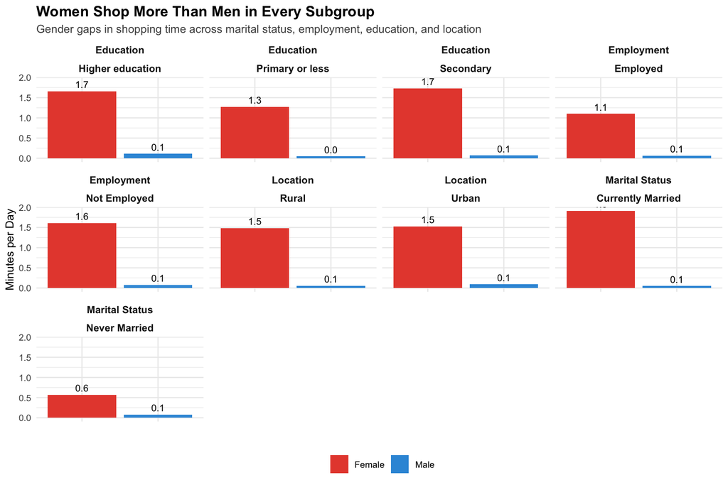

The Shopping Gap Persists Across Marital Status, Employment, Education, and Location

# 5 Regression Analysis

## 5.1 Baseline Results

Table 5 presents linear regressions predicting shopping time.

|  | Shopping Minutes | Shopping Minutes | Shopping Participation | Shopping Participation |
| --- | --- | --- | --- | --- |
| Female | 1.432*** | 1.040*** | 0.028*** | 0.021*** |
|  | (0.017) | (0.017) | (0.000) | (0.000) |
| Age |  | 0.105*** |  | 0.002*** |
|  |  | (0.002) |  | (0.000) |
| Urban |  | -0.078*** |  | -0.001* |
|  |  | (0.020) |  | (0.000) |
| Employed |  | -0.803*** |  | -0.014*** |
|  |  | (0.025) |  | (0.000) |
| Secondary education |  | 0.160*** |  | 0.003*** |
|  |  | (0.035) |  | (0.001) |
| Higher education |  | -0.009 |  | 0.000 |
|  |  | (0.098) |  | (0.002) |
| Num.Obs. | 836052 | 836052 | 836052 | 836052 |
| R2 | 0.010 | 0.014 | 0.012 | 0.016 |

* p < 0.1, ** p < 0.05, *** p < 0.01  
Robust standard errors in parentheses. State fixed effects included in models 2 and 4.

## 5.2 Marriage and the Mental Load Transfer

Table 6 restricts to married individuals and tests employment interactions.

|  | Shopping | Shopping (Interaction) | Household Management | Mental Load (Combined) |
| --- | --- | --- | --- | --- |
| Female | 1.250*** | 1.681*** | 0.019** | 1.268*** |
|  | (0.029) | (0.041) | (0.009) | (0.030) |
| Employed | -0.846*** | -0.416*** | -0.060*** | -0.906*** |
|  | (0.036) | (0.034) | (0.011) | (0.038) |
| Female × Employed |  | -0.557*** |  |  |
|  |  | (0.053) |  |  |
| Age | 0.018*** | 0.011* | 0.004* | 0.022*** |
|  | (0.006) | (0.006) | (0.002) | (0.006) |
| Urban | -0.040 | -0.040 | -0.014 | -0.054* |
|  | (0.030) | (0.030) | (0.009) | (0.031) |
| Num.Obs. | 522268 | 522268 | 522268 | 522268 |
| R2 | 0.015 | 0.015 | 0.001 | 0.015 |

* p < 0.1, ** p < 0.05, *** p < 0.01  
Robust standard errors in parentheses. State fixed effects and education controls included in all models.

## 5.3 Education and Urban Residence: No Escape from Mental Load

|  | Shopping | Mental Load | Shopping | Mental Load |
| --- | --- | --- | --- | --- |
| Female | 1.005*** | 1.046*** | 1.045*** | 1.090*** |
|  | (0.017) | (0.018) | (0.020) | (0.021) |
| Urban | -0.069*** | -0.085*** | -0.069*** | -0.067*** |
|  | (0.020) | (0.021) | (0.011) | (0.013) |
| Female × Urban |  |  | -0.017 | -0.047 |
|  |  |  | (0.035) | (0.037) |
| Num.Obs. | 836052 | 836052 | 836052 | 836052 |
| R2 | 0.014 | 0.014 | 0.014 | 0.014 |

* p < 0.1, ** p < 0.05, *** p < 0.01  
Robust standard errors in parentheses. State fixed effects included in all models.

**Key Finding**: The gendered mental load persists regardless of education or urbanization, suggesting deeply ingrained norms about women’s responsibility for household planning and organization.

# 6 Discussion and Mechanisms

## 6.1 What Explains the Gendered Mental Load?

Our findings document substantial gender gaps in shopping and household management—activities that capture the cognitive and organizational dimensions of household work. Women spend substantially more time shopping than men overall, and this gap is even larger among married couples. These gaps persist across education levels, urban-rural locations, and employment status.

What explains this persistent gendered mental load? Our empirical patterns point to several mechanisms:

### 6.1.1 Cultural Norms Dominate Economic Incentives

**The evidence against economic specialization:** Our results strongly contradict efficiency-based specialization theories (Becker 1981):

1. **Education provides no escape**: Table 4 shows that highly educated women do 15.1 times as much shopping as highly educated men. If specialization were efficient, educated couples with similar wage rates should show minimal gaps.
2. **Employment barely reduces women’s burden**: Table 3 shows employed women reduce shopping by only 31%, while employed men’s time is unchanged. If households optimized based on opportunity costs, employed women should dramatically reduce shopping.
3. **Urban-rural patterns are identical**: Table 7 shows no Female × Urban interaction—gender gaps are equally large in urban and rural areas, despite different labor markets and opportunities.

**The evidence for gender norms:** These null results suggest that shopping is assigned to women regardless of economic logic, pointing to deeply ingrained cultural norms about women’s role as “household managers” (Daminger 2019). In India’s patriarchal context, wives are expected to manage household logistics even when this conflicts with economic efficiency.

### 6.1.2 Marriage as a Critical Transition

Our finding that marriage amplifies the shopping gap (Table 2) from 7.3x to 37.3x suggests that marriage represents a critical moment when household management responsibilities are gendered and assigned. Several India-specific factors likely drive this:

1. **Patrilocal marriage**: Brides typically move to husbands’ households (Desai and Andrist 2010), where they take over domestic responsibilities from mothers-in-law or establish new households requiring full management.
2. **Joint family dynamics**: In joint families, multiple women (mother-in-law, daughters-in-law) may divide shopping, but men remain exempt.
3. **Marital bargaining power**: Newly married women in India typically have low bargaining power and cannot negotiate for equal sharing of household management.

### 6.1.3 The Pre-Marriage Gender Gap: Early Socialization

The baseline gap among never-married individuals (women shop 7.3x as much as men before marriage) suggests that gender norms about household planning are instilled early, likely through:

- **Childhood training**: Girls help mothers shop and learn household management; boys do not
- **Contributions to natal family**: Never-married daughters help with parental household shopping; sons are exempted
- **Gendered competencies**: By early adulthood, women have developed shopping skills while men lack them

This early differentiation means marriage amplifies rather than creates the inequality.

## 6.2 Why Doesn’t the Gap Narrow with Modernization?

We find no evidence that education or urbanization narrows the mental load gap. This is puzzling because: - Educated individuals hold more egalitarian gender attitudes - Urban areas expose people to dual-earner norms and egalitarian ideals - Middle-class urban couples in India increasingly frame themselves as “modern” and “equal”

One interpretation: the mental load may be especially resistant to change precisely because it is **invisible**. Couples may believe they share household work equally because they share visible tasks (he cooks dinner sometimes, she does laundry), while the underlying cognitive work—planning meals, tracking supplies, scheduling activities—remains entirely on women’s shoulders.

## 6.3 Policy Implications

Our findings suggest that household planning and procurement responsibilities are deeply gendered in India, resistant to education and employment, and amplified by marriage. What policy interventions might address these patterns?

### 6.3.1 Target Marriage as Critical Transition Point

Since marriage amplifies the shopping gap from 7.3x to 37.3x (Table 2), marriage represents a critical intervention point:

- **Pre-marital counseling programs** could explicitly address household management expectations and negotiate equal sharing before patterns solidify
- **Newlywed couples programs** could provide tools and support for establishing egalitarian household management from the start
- **Mother-in-law engagement**: In patrilocal households, mothers-in-law wield significant influence; programs engaging them in norm change could be effective

### 6.3.2 Address the Double Burden for Employed Women

Employed women reduce shopping by only 31% despite time constraints (Table 3). To support employed women:

- **Workplace flexibility**: Policies allowing flexible hours for household errands (currently stigmatized for women) could be normalized
- **Grocery delivery infrastructure**: In 2019 India, delivery services were limited; expanding access (especially outside major cities) could reduce time burdens
- **Affordable prepared foods**: The lack of time-saving food options forces employed women to maintain full shopping responsibilities
- **Employer-provided services**: Workplace-based grocery ordering or household service coordination could reduce employed women’s burdens

However, these solutions risk reinforcing women’s responsibility rather than redistributing it to men. Infrastructure must be paired with norm change targeting men.

### 6.3.3 Childhood and Adolescent Socialization

The baseline gap among never-married individuals suggests early gender socialization. Interventions should target children and adolescents:

- **Life skills education for boys**: Schools should teach all students (not just girls) budgeting, meal planning, and household organization
- **Equal task assignment at home**: Public campaigns encouraging parents to assign shopping/planning tasks equally to sons and daughters
- **Media and role modeling**: Visibility of men engaging in shopping and household planning in media could shift norms

### 6.3.4 Infrastructure Alone Is Insufficient

Our finding that educated and urban couples show gaps as large as uneducated and rural couples (Tables 4, 7) suggests that modernization and exposure to egalitarian norms are insufficient without explicit norm change. Technology and services can reduce the burden but may simply make women more efficient household managers rather than shifting responsibilities to men.

Policy must explicitly target the cultural norm that household management is “women’s work”—through campaigns, education, and institutional change.

## 6.4 Limitations

Our study has limitations:

1. **Lower bound estimate**: We capture only observable shopping and management time, missing the background cognitive work of planning, remembering, and worrying. True mental load gaps likely exceed our estimates.
2. **Can’t distinguish planner from executor**: If a man shops using his wife’s list, we attribute shopping to him even though she did the planning. This may understate women’s cognitive contributions.
3. **Cross-sectional data**: We cannot identify causal effects of marriage or employment on shopping patterns. Future research with panel data or policy reforms could shed light on mechanisms.
4. **Cultural specificity**: India has strong patriarchal norms that may amplify mental load gender gaps. Patterns in more egalitarian societies may differ.

# 7 Conclusion

Crucially, these gaps persist among employed women and the highly educated, suggesting that the mental load is resistant to economic incentives and modernization. Employed women maintain high levels of shopping activity despite time constraints from paid work, while men’s shopping time is unaffected by employment. Educated women and men show similar gaps to less-educated couples.

Our findings reveal that beyond the visible tasks of cooking, cleaning, and childcare, women bear disproportionate responsibility for shopping and household management activities that involve planning, organizing, and coordinating household needs. While time-use data captures observable activities rather than cognitive burden directly, these patterns likely reflect a broader “mental load”—the responsibility to plan, remember, coordinate, and ensure household functioning. This dimension of household labor remains invisible in policy discussions focused on task-sharing, yet may be central to understanding persistent gender inequality in time use, labor force participation, and wellbeing.

Addressing this requires not just redistributing tasks but making the mental load visible, challenging norms that assign women primary responsibility for household management, and designing policies and technologies that support shared planning and coordination.

Without such measures, apparent progress in sharing household tasks may mask continued inequality in who bears the cognitive and emotional burden of managing domestic life.

# 8 References

Arora, Dolly. 2015. “Gender Differences in Time-Poverty in Rural Rajasthan, India: Measurement and Decomposition.” *Feminist Economics* 21(4): 160-187.

Becker, Gary S. 1981. *A Treatise on the Family*. Cambridge, MA: Harvard University Press.

Bianchi, Suzanne M., Melissa A. Milkie, Liana C. Sayer, and John P. Robinson. 2000. “Is Anyone Doing the Housework? Trends in the Gender Division of Household Labor.” *Social Forces* 79(1): 191-228.

Bittman, Michael, Paula England, Liana Sayer, Nancy Folbre, and George Matheson. 2003. “When Does Gender Trump Money? Bargaining and Time in Household Work.” *American Journal of Sociology* 109(1): 186-214.

Bonke, Jens. 2019. “Paid Work, Housework and Work-Life Balance: A 35-Year Perspective on Danish Fathers and Mothers’ Time Use.” *Community, Work & Family* 22(5): 535-553.

Carlson, Daniel L., Richard J. Petts, and Joanna R. Pepin. 2020. “Flexplace Work and Partnered Fathers’ Time in Housework and Childcare.” *Men and Masculinities* 23(2): 247-270.

Ciciolla, Lucia, and Suniya S. Luthar. 2019. “Invisible Household Labor and Ramifications for Adjustment: Mothers as Captains of Households.” *Sex Roles* 81: 467-486.

Craig, Lyn, and Killian Mullan. 2011. “How Mothers and Fathers Share Childcare: A Cross-National Time-Use Comparison.” *American Sociological Review* 76(6): 834-861.

Dean, Lorraine, Fiona Churchill, Mary Ruppanner, et al. 2022. “The Mental Load: Building a Deeper Theoretical Understanding of How Cognitive and Emotional Labor Overload Women and Mothers.” *Community, Work & Family* 25(1): 13-29.

Desai, Sonalde, and Lester Andrist. 2010. “Gender Scripts and Age at Marriage in India.” *Demography* 47(3): 667-687.

Daminger, Allison. 2019. “The Cognitive Dimension of Household Labor.” *American Sociological Review* 84(4): 609-633.

Gronau, Reuben. 1977. “Leisure, Home Production, and Work—The Theory of the Allocation of Time Revisited.” *Journal of Political Economy* 85(6): 1099-1123.

Hartley, Gemma. 2018. *Fed Up: Emotional Labor, Women, and the Way Forward*. New York: HarperOne.

Hochschild, Arlie. 1989. *The Second Shift: Working Parents and the Revolution at Home*. New York: Viking.

Kan, Man Yee, and Stephen Pudney. 2008. “Measurement Error in Stylized and Diary Data on Time Use.” *Sociological Methodology* 38(1): 101-132.

Klasen, Stephan, and Janneke Pieters. 2015. “What Explains the Stagnation of Female Labor Force Participation in Urban India?” *World Bank Economic Review* 29(3): 449-478.

Kotsadam, Andreas, and Henning Finseraas. 2011. “The State Intervenes in the Battle of the Sexes: Causal Effects of Paternity Leave.” *Social Science Research* 40(6): 1611-1622.

Kulkarni, Veena S. 2020. “Women’s Time Poverty and Unpaid Work in India.” *Review of Economics of the Household* 18(4): 891-917.

Lachance-Grzela, Mylène, and Geneviève Bouchard. 2010. “Why Do Women Do the Lion’s Share of Housework? A Decade of Research.” *Sex Roles* 63: 767-780.

Offer, Shira, and Barbara Schneider. 2011. “Revisiting the Gender Gap in Time-Use Patterns: Multitasking and Well-Being among Mothers and Fathers in Dual-Earner Families.” *American Sociological Review* 76(6): 809-833.

Sayer, Liana C. 2005. “Gender, Time and Inequality: Trends in Women’s and Men’s Paid Work, Unpaid Work and Free Time.” *Social Forces* 84(1): 285-303.

Sullivan, Oriel. 2013. “What Do We Learn About Gender by Analyzing Housework Separately from Child Care? Some Considerations from Time-Use Evidence.” *Journal of Family Theory & Review* 5(2): 72-84.

Walzer, Susan. 1996. “Thinking About the Baby: Gender and Divisions of Infant Care.” *Social Problems* 43(2): 219-234.

West, Candace, and Don H. Zimmerman. 1987. “Doing Gender.” *Gender & Society* 1(2): 125-151.

[^1]: Blue Machines, preetdeepsingh111@yahoo.com